# Predicting sentiment from product reviews

### Due: Wednesday, April 25th, at 11:59 pm on Canvas

The goal of this first notebook is to explore logistic regression and feature engineering with existing Turi Create functions.

In this notebook you will use product review data from Amazon.com to predict whether the sentiments about a product (from its reviews) are positive or negative.

- Use SFrames to do some feature engineering
- Train a logistic regression model to predict the sentiment of product reviews.
- Inspect the weights (coefficients) of a trained logistic regression model.
- Make a prediction (both class and probability) of sentiment for a new product review.
- Given the logistic regression weights, predictors and ground truth labels, write a function to compute the **accuracy** of the model.
- Inspect the coefficients of the logistic regression model and interpret their meanings.
- Compare multiple logistic regression models.

Copyright ©2018 Emily Fox. All rights reserved. Permission is hereby granted to students registered for University of Washington CSE/STAT 416 for use solely during Spring Quarter 2018 for purposes of the course. No other use, copying, distribution, or modification is permitted without prior written consent. Copyrights for third-party components of this work must be honored. Instructors interested in reusing these course materials should contact the author.

```python
from __future__ import division
import turicreate as tc
import math
import string
import matplotlib.pyplot as plt
%matplotlib inline
```

# Data preperation

We will use a dataset consisting of baby product reviews on Amazon.com.

```python
products = tc.SFrame('/data/amazon_baby_subset.gl')
products
```

| name | review | rating |
| --- | --- | --- |
| Stop Pacifier Sucking without tears with ... | All of my kids have cried non-stop when I tried to ... | 5.0 |
| Nature's Lullabies Second Year Sticker Calendar ... | We wanted to get something to keep track ... | 5.0 |
| Nature's Lullabies Second Year Sticker Calendar ... | I only purchased a second-year calendar for ... | 2.0 |
| Nature's Lullabies Second Year Sticker Calendar ... | My daughter had her 1st baby over a year ago. ... | 5.0 |
| Lamaze Peekaboo, I Love You ... | One of baby's first and favorite books, and i ... | 4.0 |
| SoftPlay Giggle Jiggle Funbook, Happy Bear ... | This bear is absolutely adorable and I would ... | 2.0 |
| SoftPlay Peek-A-Boo Where's Elmo A Childr ... | Very cute interactive book! My son loves this ... | 5.0 |
| SoftPlay Cloth Book, Love | This book is boring. Nothing to stimulate my ... | 1.0 |
| Our Baby Girl Memory Book | Beautiful book, I love it to record cherished t ... | 5.0 |
| Hunnt&reg; Falling Flowers and Birds Kids ... | Try this out for a spring project !Easy ,fun and ... | 5.0 |

[52449 rows x 3 columns]  
Note: Only the head of the SFrame is printed.  
You can use print_rows(num_rows=m, num_columns=n) to print more rows and columns.

Now, let us see a preview of what the dataset looks like.

## Build the word count vector for each review

Let us explore a specific example of a baby product.

```python
products[210]
```

```
{'name': 'Summer Infant, Ultimate Training Pad - Twin Mattress, 38&quot; x 28&quot;',
 'rating': 5.0,
 'review': 'Love this thing.. what a bed saver... I was finishing potty training my 2 year old and bed time was my biggest concern.  But with this I do not have to worry about the foam mattress I have on my daughters bed.  It is easy to wash and put back on the bed.. love this thing.'}
```

Now, we will perform 2 simple data transformations:

1. Remove punctuation using [Python's built-in](https://docs.python.org/2/library/string.html) string functionality.
2. Transform the reviews into word-counts.

**Aside**. In this notebook, we remove all punctuations for the sake of simplicity. A smarter approach to punctuations would preserve phrases such as "I'd", "would've", "hadn't" and so forth. See this page for an example of smart handling of punctuations.

```python
def remove_punctuation(text):
    return text.translate(None, string.punctuation)

products['review_clean'] = products['review'].apply(remove_punctuation)
products['word_count'] = tc.text_analytics.count_words(products['review_clean'])
```

```
Using default 16 lambda workers.
```

```
To maximize the degree of parallelism, add the following code to the beginning of the program:
```

```
"turicreate.set_runtime_config('TURI_DEFAULT_NUM_PYLAMBDA_WORKERS', 24)"
```

```
Note that increasing the degree of parallelism also increases the memory footprint.
```

Now, let us explore what the sample example above looks like after these 2 transformations. Here, each entry in the **word_count** column is a dictionary where the key is the word and the value is a count of the number of times the word occurs.

```python
products[210]['word_count']
```

```
{'2': 1,
 'a': 1,
 'about': 1,
 'and': 2,
 'back': 1,
 'bed': 4,
 'biggest': 1,
 'but': 1,
 'concern': 1,
 'daughters': 1,
 'do': 1,
 'easy': 1,
 'finishing': 1,
 'foam': 1,
 'have': 2,
 'i': 3,
 'is': 1,
 'it': 1,
 'love': 2,
 'mattress': 1,
 'my': 3,
 'not': 1,
 'old': 1,
 'on': 2,
 'potty': 1,
 'put': 1,
 'saver': 1,
 'the': 2,
 'thing': 2,
 'this': 3,
 'time': 1,
 'to': 2,
 'training': 1,
 'was': 2,
 'wash': 1,
 'what': 1,
 'with': 1,
 'worry': 1,
 'year': 1}
```

## Extract sentiments

We will **ignore** all reviews with *rating = 3*, since they tend to have a neutral sentiment.

```python
products = products[products['rating'] != 3]
len(products)
```

```
52448
```

Now, we will assign reviews with a rating of 4 or higher to be *positive* reviews, while the ones with rating of 2 or lower are *negative*. For the sentiment column, we use +1 for the positive class label and -1 for the negative class label.

```python
products['sentiment'] = products['rating'].apply(lambda rating : +1 if rating > 3 else -1)
products
```

| name | review | rating | review_clean |
| --- | --- | --- | --- |
| Stop Pacifier Sucking without tears with ... | All of my kids have cried non-stop when I tried to ... | 5.0 | All of my kids have cried nonstop when I tried to ... |
| Nature's Lullabies Second Year Sticker Calendar ... | We wanted to get something to keep track ... | 5.0 | We wanted to get something to keep track ... |
| Nature's Lullabies Second Year Sticker Calendar ... | I only purchased a second-year calendar for ... | 2.0 | I only purchased a secondyear calendar for ... |
| Nature's Lullabies Second Year Sticker Calendar ... | My daughter had her 1st baby over a year ago. ... | 5.0 | My daughter had her 1st baby over a year ago She ... |
| Lamaze Peekaboo, I Love You ... | One of baby's first and favorite books, and i ... | 4.0 | One of babys first and favorite books and it is ... |
| SoftPlay Giggle Jiggle Funbook, Happy Bear ... | This bear is absolutely adorable and I would ... | 2.0 | This bear is absolutely adorable and I would ... |
| SoftPlay Peek-A-Boo Where's Elmo A Childr ... | Very cute interactive book! My son loves this ... | 5.0 | Very cute interactive book My son loves this ... |
| SoftPlay Cloth Book, Love | This book is boring. Nothing to stimulate my ... | 1.0 | This book is boring Nothing to stimulate my ... |
| Our Baby Girl Memory Book | Beautiful book, I love it to record cherished t ... | 5.0 | Beautiful book I love it to record cherished t ... |
| Hunnt&reg; Falling Flowers and Birds Kids ... | Try this out for a spring project !Easy ,fun and ... | 5.0 | Try this out for a spring project Easy fun and ... |

| word_count | sentiment |
| --- | --- |
| {'and': 2, 'all': 2, 'help': 1, 'cried': 1, ... | 1 |
| {'and': 2, 'cute': 1, 'childs': 1, 'is': 1, ... | 1 |
| {'and': 1, 'cute': 1, 'because': 2, 'just': 1, ... | -1 |
| {'and': 2, 'work': 1, 'old': 1, 'sweet': 1, ... | 1 |
| {'and': 2, 'because': 1, 'family': 1, 'people' ... | 1 |
| {'and': 3, 'cute': 1, 'rating': 1, ... | -1 |
| {'cute': 1, 'great': 1, 'colorful': 1, 'for': 1, ... | 1 |
| {'a': 1, 'this': 1, 'money': 1, 'would': 1, ... | -1 |
| {'pink': 1, 'pastel': 1, 'life': 1, 'love': 1, ... | 1 |
| {'affordable': 1, 'try': 1, 'and': 2, 'room': 1, ... | 1 |

[52448 rows x 6 columns]  
Note: Only the head of the SFrame is printed.  
You can use print_rows(num_rows=m, num_columns=n) to print more rows and columns.

Now, we can see that the dataset contains an extra column called **sentiment** which is either positive (+1) or negative (-1).

## Split data into training and test sets

Let's perform a train/test split with 80% of the data in the training set and 20% of the data in the test set. We use `seed=1` so that everyone gets the same result.

```python
train_data, test_data = products.random_split(.8, seed=1)
print len(train_data)
print len(test_data)
```

```
41985
10463
```

## Baseline: Majority class prediction

It is quite common to use the **majority class classifier** as the a baseline (or reference) model for comparison with your classifier model. The majority classifier model predicts the majority class for all data points. At the very least, you should healthily beat the majority class classifier, otherwise, the model is (usually) pointless.

What is the majority class in the **train_data**?

```python
num_positive  = (train_data['sentiment'] == +1).sum()
num_negative = (train_data['sentiment'] == -1).sum()
print num_positive
print num_negative
```

```
20949
21036
```

Now compute the accuracy of the majority class classifier on **test_data**.

**Quiz Question**: Enter the accuracy of the majority class classifier model on the **test_data**. Round your answer to two decimal places (e.g. 0.76).

```python
num_positive  = (test_data['sentiment'] == +1).sum()
num_negative = (test_data['sentiment'] == -1).sum()
print num_positive
print num_negative
print 5129/10463
```

```
5334
5129
0.490203574501
```

# Train a sentiment classifier with logistic regression

We will now use logistic regression to create a sentiment classifier on the training data. This model will use the column **word_count** as a feature and the column **sentiment** as the target. We will use `validation_set=None` to obtain same results as everyone else, and set the `l1_penalty=0` and `l2_penalty=0`.

**Note:** This line may take 1-2 minutes.

```python
sentiment_model = tc.logistic_classifier.create(train_data,
                                                target = 'sentiment',
                                                features=['word_count'],
                                                validation_set=None, l1_penalty=0, l2_penalty=0)
```

```
WARNING: The number of feature dimensions in this problem is very large in comparison with the number of examples. Unless an appropriate regularization value is set, this model may not provide accurate predictions for a validation/test set.
```

```
Logistic regression:
```

```
Number of examples          : 41985
```

```
Number of classes           : 2
```

```
Number of feature columns   : 1
```

```
Number of unpacked features : 61175
```

```
Number of coefficients      : 61176
```

```
Starting L-BFGS
```

```
+-----------+----------+-----------+--------------+-------------------+
```

```
| Iteration | Passes   | Step size | Elapsed Time | Training-accuracy |
```

```
+-----------+----------+-----------+--------------+-------------------+
```

```
| 1         | 3        | 0.000024  | 1.203162     | 0.815625          |
```

```
| 2         | 5        | 1.000000  | 1.362867     | 0.928474          |
```

```
| 3         | 6        | 1.000000  | 1.461724     | 0.936882          |
```

```
| 4         | 7        | 1.000000  | 1.555146     | 0.962653          |
```

```
| 5         | 8        | 1.000000  | 1.671472     | 0.972824          |
```

```
| 6         | 9        | 1.000000  | 1.768167     | 0.943575          |
```

```
| 10        | 14       | 1.000000  | 2.246208     | 0.983851          |
```

```
+-----------+----------+-----------+--------------+-------------------+
```

```
TERMINATED: Iteration limit reached.
```

```
This model may not be optimal. To improve it, consider increasing `max_iterations`.
```

```python
sentiment_model.coefficients
```

| name | index | class | value | stderr |
| --- | --- | --- | --- | --- |
| (intercept) | None | 1 | 0.0594285255049 | None |
| word_count | rock | 1 | -0.224703091957 | None |
| word_count | headachesthanks | 1 | 1.65486590536 | None |
| word_count | many | 1 | 0.189948219369 | None |
| word_count | soo | 1 | -0.244120041722 | None |
| word_count | will | 1 | -0.00622313744865 | None |
| word_count | expecting | 1 | 0.085960910195 | None |
| word_count | fairy | 1 | 1.73222074988 | None |
| word_count | binky | 1 | 0.748767644585 | None |
| word_count | your | 1 | -0.110181380114 | None |

[61176 rows x 5 columns]  
Note: Only the head of the SFrame is printed.  
You can use print_rows(num_rows=m, num_columns=n) to print more rows and columns.

Now that we have fitted the model, we can extract the weights (coefficients) as an SFrame as follows:

```python
weights = sentiment_model.coefficients
weights.column_names()
len(weights)
```

```
61176
```

There are a total of `61176` coefficients in the model. Recall from the lecture that positive weights $w_j$ correspond to weights that cause positive sentiment, while negative weights correspond to negative sentiment.

Fill in the following block of code to calculate how many *weights* are positive ( >= 0). (**Hint**: The `'value'` column in SFrame *weights* must be positive ( >= 0)).

```python
# print "Number of positive weights: %s " % (...).sum()
# print "Number of negative weights: %s " % (...).sum()
print (weights['value'] >= 0).sum()
print (weights['value'] < 0).sum()
```

```
28662
32514
```

**Quiz question:** How many weights are >= 0?

## Making predictions with logistic regression

Now that a model is trained, we can make predictions on the **test data**. In this section, we will explore this in the context of 3 examples in the test dataset. We refer to this set of 3 examples as the **sample_test_data**.

```python
sample_test_data = test_data[10:13]
```

Let's dig deeper into the first row of the **sample_test_data**. Here's the full review:

```python
sample_test_data[0]['review']
```

```
"This is a must have for any toddler!  I bought one for my brothers triplets who were 1 1/2 years old at the time.  They loved it!  One would push & the other 2 would chase after it.  They love watching the duck waddle & its feet go round & round.  Best of all, no batteries!  Yaayyyy!!Fifteen years …
```

That review seems pretty positive.

Now, let's see what the another row of the **sample_test_data** looks like. As we could guess from the sentiment (-1), the review is quite negative.

```python
sample_test_data[2]['review']
```

```
'I would recommend getting cheaper sheets made for a playpen. These started unraveling after one wash! Not worth the money.'
```

### Predicting sentiment

Run the following Turi Create code to make predictions.

```python
print "Probability predictions on the sample test data:"
print sentiment_model.predict(sample_test_data, output_type='probability')
```

```
Probability predictions on the sample test data:
[0.996289053384975, 0.685906276557803, 0.19121671558056696]
```

**Quiz question:** Of the three data points in **sample_test_data**, which one (first, second, or third) has the **lowest probability** of being classified as a positive review?

```python
print "Predicted labels on the sample test data:"
print sentiment_model.predict(sample_test_data)
```

```
Predicted labels on the sample test data:
[1, 1, -1]
```

# Find the most positive (and negative) review

We now turn to examining the full test dataset, **test_data**, and use Turi Create to form predictions on all of the test data points for faster performance.

Using the `sentiment_model`, find the review in the entire **test_data** with the **highest probability** of being classified as a **positive review**. We refer to this as the "most positive review."

To calculate these most positive review, use the following steps:

1. Make probability predictions on **test_data** using the `sentiment_model`. (**Hint:** When you call `.predict` to make predictions on the test data, use option `output_type='probability'` to output the probability rather than just the most likely class.)
2. Sort the data in descending order according to those predictions, breaking ties on names and pick the best. **Hint:** `.sort` [(API Link)](https://apple.github.io/turicreate/docs/api/generated/turicreate.SFrame.sort.html#turicreate.SFrame.sort) will return a sorted SFrame (so make sure to save it before indexing into it). It can also take a list of multiple columns to sort by to break ties. Check out the examples in the API.
3. Add a column to test data called 'predictions' to store your predictions.

```python
# test_data['predictions'] = ...
# test_data = ...
# ... # extract out the most positive product
test_data['predictions'] = sentiment_model.predict(test_data, output_type = 'probability')
test_data_sorted = test_data.sort([('predictions', False), ('name', False)])
most_positive = test_data_sorted[0]
```

Read the review and see if it sounds positive.

```python
most_positive['name']
```

```
"The First Years Compass B540 Booster Seat, Abstract O's"
```

Now, let us repeat this excercise to find the "most negative review." Use the prediction probabilities to find the review in the **test_data** with the **lowest probability** of being classified as a **positive review**. Repeat the same steps above but make sure you **sort in the opposite order**, or if you've already saved the sorted SFrame, you can index in from the end using negative indices.

```python
test_data_sorted = test_data.sort([('predictions', True), ('name', True)])
```

Read the review and see if it sounds negative.

```python
test_data_sorted[0]['name']
```

```
'Arms Reach Co-Sleeper brand Mini Co-Sleeper Bassinet - Natural'
```

**Quiz Question**: Which of the following products has the most positive review? [multiple choice]  
**Quiz Question**: Which of the following products has the most negative review? [multiple choice]

## Compute accuracy of the classifier

We will now evaluate the accuracy of the trained classifer. Recall that the accuracy is given by

$$ \mbox{accuracy} = \frac{\mbox{# correctly classified examples}}{\mbox{# total examples}} $$

This can be computed as follows:

- **Step 1:** Use the trained model to compute class predictions (**Hint:** Use the `predict` method)
- **Step 2:** Count the number of data points when the predicted class labels match the ground truth labels (called `true_labels` below).
- **Step 3:** Divide the total number of correct predictions by the total number of data points in the dataset.

Complete the function below to compute the classification accuracy:

```python
def get_classification_accuracy(model, data, true_labels):
    # First get the predictions
    ## YOUR CODE HERE
    # predictions = ...
    predictions = model.predict(data, output_type = 'probability')

    # Compute the number of correctly classified examples
    ## YOUR CODE HERE
    # num_correct = ...
    num_correct = ((predictions > 0.5) == (true_labels)).sum() + (-(predictions < 0.5) == (true_labels)).sum()
    # Then compute accuracy by dividing num_correct by total number of examples
    ## YOUR CODE HERE
    # accuracy = ...
    accuracy = num_correct/len(predictions)
    return accuracy
```

Now, let's compute the classification accuracy of the **sentiment_model** on the **test_data**.

```python
get_classification_accuracy(sentiment_model, test_data, test_data['sentiment'])
```

```
0.8806269712319602
```

**Quiz Question**: What is the accuracy of the **sentiment_model** on the **test_data**? Round your answer to 2 decimal places (e.g. 0.76).

**Quiz Question**: Should we use the **sentiment_model** or the **majority class classifier (the baseline model)**?

### Logistic Regression with L2 regularization

We compiled a list of 193 most frequent words into the JSON file named important_words.json. Load the words into a list important_words. We're going to load them in and create column with the count for each of the words. We're doing this so that we can observe the effect of L2 regularization on the features.

```python
# Split out the words into individual columns
import json
with open('/data/important_words.json', 'r') as f: # Reads the list of most frequent words
    important_words = json.load(f)
important_words = [str(s) for s in important_words]

important_words
```

```
['baby',
 'one',
 'great',
 'love',
 'use',
 'would',
 'like',
 'easy',
 'little',
 'seat',
 'old',
 'well',
 'get',
 'also',
 'really',
 'son',
 'time',
 'bought',
 'product',
 'good',
 'daughter',
 'much',
 'loves',
 'stroller',
 'put',
 'months',
 'car',
 'still',
 'back',
 'used',
 'recommend',
 'first',
 'even',
 'perfect',
 'nice',
 'bag',
 'two',
 'using',
 'got',
 'fit',
```

[output cut: 138 more lines]

```
 'less',
 'went',
 'working',
 'high',
 'unit',
 'seems',
 'picture',
 'completely',
 'wish',
 'buying',
 'babies',
 'won',
 'tub',
 'almost',
 'either']
```

We're going to create a new column for each of the words in `important_words` and fill in their word counts from each of the reviews.

```python
for word in important_words:
    products[word] = products['review_clean'].apply(lambda s : s.split().count(word))
```

Now, let us take a look at what the dataset looks like (**Note:** This could take a while).

```python
products
```

| name | review | rating | review_clean |
| --- | --- | --- | --- |
| Stop Pacifier Sucking without tears with ... | All of my kids have cried non-stop when I tried to ... | 5.0 | All of my kids have cried nonstop when I tried to ... |
| Nature's Lullabies Second Year Sticker Calendar ... | We wanted to get something to keep track ... | 5.0 | We wanted to get something to keep track ... |
| Nature's Lullabies Second Year Sticker Calendar ... | I only purchased a second-year calendar for ... | 2.0 | I only purchased a secondyear calendar for ... |
| Nature's Lullabies Second Year Sticker Calendar ... | My daughter had her 1st baby over a year ago. ... | 5.0 | My daughter had her 1st baby over a year ago She ... |
| Lamaze Peekaboo, I Love You ... | One of baby's first and favorite books, and i ... | 4.0 | One of babys first and favorite books and it is ... |
| SoftPlay Giggle Jiggle Funbook, Happy Bear ... | This bear is absolutely adorable and I would ... | 2.0 | This bear is absolutely adorable and I would ... |
| SoftPlay Peek-A-Boo Where's Elmo A Childr ... | Very cute interactive book! My son loves this ... | 5.0 | Very cute interactive book My son loves this ... |
| SoftPlay Cloth Book, Love | This book is boring. Nothing to stimulate my ... | 1.0 | This book is boring Nothing to stimulate my ... |
| Our Baby Girl Memory Book | Beautiful book, I love it to record cherished t ... | 5.0 | Beautiful book I love it to record cherished t ... |
| Hunnt&reg; Falling Flowers and Birds Kids ... | Try this out for a spring project !Easy ,fun and ... | 5.0 | Try this out for a spring project Easy fun and ... |

| word_count | sentiment | baby | one | great | love | use | would | like | easy | little | seat | old |
| --- | --- | --- | --- | --- | --- | --- | --- | --- | --- | --- | --- | --- |
| {'and': 2, 'all': 2, 'help': 1, 'cried': 1, ... | 1 | 0 | 0 | 1 | 0 | 0 | 0 | 0 | 1 | 0 | 0 | 0 |
| {'and': 2, 'cute': 1, 'childs': 1, 'is': 1, ... | 1 | 0 | 0 | 0 | 0 | 0 | 0 | 0 | 0 | 0 | 0 | 0 |
| {'and': 1, 'cute': 1, 'because': 2, 'just': 1, ... | -1 | 0 | 3 | 0 | 0 | 0 | 0 | 0 | 0 | 0 | 0 | 0 |
| {'and': 2, 'work': 1, 'old': 1, 'sweet': 1, ... | 1 | 1 | 0 | 0 | 0 | 0 | 0 | 0 | 0 | 0 | 0 | 1 |
| {'and': 2, 'because': 1, 'family': 1, 'people' ... | 1 | 0 | 0 | 0 | 0 | 0 | 0 | 1 | 0 | 0 | 0 | 0 |
| {'and': 3, 'cute': 1, 'rating': 1, ... | -1 | 0 | 0 | 0 | 0 | 0 | 2 | 1 | 0 | 0 | 0 | 0 |
| {'cute': 1, 'great': 1, 'colorful': 1, 'for': 1, ... | 1 | 0 | 0 | 1 | 0 | 0 | 0 | 0 | 0 | 0 | 0 | 0 |
| {'a': 1, 'this': 1, 'money': 1, 'would': 1, ... | -1 | 0 | 0 | 0 | 0 | 0 | 1 | 0 | 0 | 0 | 0 | 0 |
| {'pink': 1, 'pastel': 1, 'life': 1, 'love': 1, ... | 1 | 0 | 0 | 1 | 1 | 0 | 0 | 0 | 0 | 0 | 0 | 0 |
| {'affordable': 1, 'try': 1, 'and': 2, 'room': 1, ... | 1 | 0 | 0 | 0 | 0 | 0 | 0 | 0 | 0 | 0 | 0 | 0 |

| well | get | also | really | son | time | bought | product | good | daughter | much | loves | stroller | put | months |
| --- | --- | --- | --- | --- | --- | --- | --- | --- | --- | --- | --- | --- | --- | --- |
| 0 | 0 | 0 | 0 | 0 | 0 | 0 | 0 | 0 | 0 | 0 | 0 | 0 | 0 | 0 |
| 0 | 1 | 0 | 0 | 0 | 0 | 0 | 0 | 0 | 0 | 0 | 0 | 0 | 0 | 0 |
| 0 | 0 | 0 | 1 | 1 | 0 | 0 | 0 | 0 | 1 | 0 | 0 | 0 | 0 | 0 |
| 0 | 1 | 0 | 0 | 1 | 0 | 0 | 0 | 0 | 1 | 0 | 0 | 0 | 0 | 0 |
| 0 | 0 | 0 | 0 | 0 | 0 | 0 | 0 | 0 | 0 | 0 | 0 | 0 | 0 | 0 |
| 0 | 0 | 0 | 0 | 0 | 0 | 0 | 0 | 0 | 0 | 0 | 0 | 0 | 0 | 0 |
| 0 | 0 | 0 | 0 | 1 | 0 | 0 | 0 | 0 | 0 | 0 | 1 | 0 | 0 | 0 |
| 0 | 0 | 0 | 0 | 0 | 0 | 0 | 0 | 0 | 0 | 0 | 0 | 0 | 0 | 0 |
| 0 | 0 | 0 | 0 | 0 | 0 | 0 | 0 | 0 | 0 | 0 | 0 | 0 | 0 | 0 |
| 0 | 0 | 0 | 0 | 0 | 0 | 0 | 0 | 0 | 0 | 0 | 0 | 0 | 0 | 0 |

| car | still | back | used | recommend | first | even | perfect | ... |
| --- | --- | --- | --- | --- | --- | --- | --- | --- |
| 0 | 0 | 0 | 0 | 0 | 0 | 0 | 0 | ... |
| 0 | 0 | 0 | 0 | 0 | 0 | 0 | 0 | ... |
| 0 | 0 | 0 | 0 | 0 | 0 | 0 | 0 | ... |
| 0 | 0 | 0 | 0 | 0 | 1 | 0 | 0 | ... |
| 0 | 0 | 0 | 0 | 0 | 1 | 0 | 1 | ... |
| 0 | 0 | 1 | 0 | 0 | 0 | 1 | 0 | ... |
| 0 | 0 | 0 | 0 | 0 | 0 | 0 | 0 | ... |
| 0 | 0 | 0 | 0 | 1 | 0 | 0 | 0 | ... |
| 0 | 0 | 0 | 0 | 0 | 0 | 0 | 0 | ... |
| 0 | 0 | 0 | 0 | 0 | 0 | 0 | 0 | ... |

[52448 rows x 199 columns]  
Note: Only the head of the SFrame is printed.  
You can use print_rows(num_rows=m, num_columns=n) to print more rows and columns.

Now that we have written up all the pieces needed for regularized logistic regression, let's explore the benefits of using **L2 regularization** in analyzing sentiment for product reviews. **As iterations pass, the log likelihood should increase**.

**TASK:** Train a model with the `important_words` as features for each of the `l2_penalties` to predict the target `sentiment`. Add a column to `table` with the respective `column_name`, and save the coefficients with the model. Set the model's `validation_set=None`.

You should end up with an SFrame with column names as 'coefficients [L2=0]', ... 'coefficients [L2=1e5]', and a row for each word in `important_words`.

Remember to set `l1_penalty=0` because we will only want to use an `l2_penalty`.

```python
l2_penalties = [0, 4, 10, 1e2, 1e3, 1e5]
l2_penalty_names = ['coefficients [L2=0]', 'coefficients [L2=4]', 'coefficients [L2=10]',
                   'coefficients [L2=1e2]', 'coefficients [L2=1e3]', 'coefficients [L2=1e5]']

# Add the coefficients to this table for each model
table = tc.SFrame({'word': ['(intercept)'] + important_words})

for l2_penalty, column_name in zip(l2_penalties, l2_penalty_names):
    model_current = tc.linear_regression.create(products, target = 'sentiment', features = important_words, validation_set = None, l2_penalty = l2_penalty, l1_penalty = 0, verbose = False)
    table[column_name] = model_current.coefficients['value']
```

You should have a table that has 194 rows and 7 columns.

```python
for column_name in l2_penalty_names:
    print ((table[column_name]-0)**2).sum()
table
```

```
2.64806904274
2.6478020206
2.64740157642
2.64140770087
2.58275644043
0.584209710172
```

| word | coefficients [L2=0] | coefficients [L2=4] | coefficients [L2=10] | coefficients [L2=1e2] |
| --- | --- | --- | --- | --- |
| (intercept) | -0.017665635046 | -0.0176596673895 | -0.0176507181317 | -0.0175167989327 |
| baby | 0.0146084717585 | 0.0146088312387 | 0.0146093696902 | 0.0146173364067 |
| one | 0.00252369486202 | 0.00252455569317 | 0.00252584577414 | 0.00254503008108 |
| great | 0.248166313533 | 0.248146805976 | 0.248117551482 | 0.247679716537 |
| love | 0.259300658092 | 0.25928635763 | 0.259264910293 | 0.258943682289 |
| use | -0.00135419117747 | -0.0013517956703 | -0.00134820396747 | -0.00129455199647 |
| would | -0.0735237549723 | -0.0735174185789 | -0.073507916835 | -0.0733657991518 |
| like | 0.00119701442406 | 0.00119583996825 | 0.00119407945684 | 0.00116783974475 |
| easy | 0.285553743533 | 0.285533814692 | 0.285503928405 | 0.285056635464 |
| little | 0.156130530959 | 0.156120493867 | 0.156105441317 | 0.155880096386 |

| coefficients [L2=1e3] | coefficients [L2=1e5] |
| --- | --- |
| -0.0162095759253 | 0.026026624262 |
| 0.014686277196 | 0.00890717335954 |
| 0.00272059877433 | 0.000850818123807 |
| 0.243400099134 | 0.0907411674189 |
| 0.255780178974 | 0.112785180657 |
| -0.000780321347459 | 0.00538378447737 |
| -0.0719853913864 | -0.0286333366356 |
| 0.000921928478185 | -0.000713055247768 |
| 0.280684024513 | 0.115724426449 |
| 0.153671131486 | 0.0641577431913 |

[194 rows x 7 columns]  
Note: Only the head of the SFrame is printed.  
You can use print_rows(num_rows=m, num_columns=n) to print more rows and columns.

## Look at the Coefficients

We'll now look at the **coefficients** for the model that were trained above. We will create a table of features and learned coefficients associated with each of the different L2 penalty values.

Using **the coefficients trained with L2 penalty 0**, find the 5 most positive words (with largest positive coefficients). Save them to **positive_words**. Similarly, find the 5 most negative words (with largest negative coefficients) and save them to **negative_words**.

**Quiz Question**. Which of the following is **not** listed in either **positive_words** or **negative_words**?

**Hint:** You can use the `.topk` [(API Link)](https://apple.github.io/turicreate/docs/api/generated/turicreate.SFrame.topk.html) method on an SFrame to find the top k rows sorted according to the value of a specified column.

```python
# positive_words = ...
# negative_words = ...
table_sorted = table.sort('coefficients [L2=0]', False)
positive_words = table_sorted.head(5)['word']
negative_words = table_sorted.tail(5)['word']
print 'Positive words:', positive_words
print 'Negative words:', negative_words
```

```
Positive words: ['loves', 'perfect', 'easy', 'happy', 'best']
Negative words: ['waste', 'idea', 'broke', 'returned', 'disappointed']
```

Let us observe the effect of increasing L2 penalty on the 10 words just selected. We provide you with a utility function to plot the coefficient path.

```python
plt.rcParams['figure.figsize'] = 10, 6

def make_coefficient_plot(table, positive_words, negative_words, l2_penalty_list):
    cmap_positive = plt.get_cmap('Reds')
    cmap_negative = plt.get_cmap('Blues')

    xx = l2_penalty_list
    plt.plot(xx, [0.]*len(xx), '--', lw=1, color='k')

    table_positive_words = table.filter_by(column_name='word', values=positive_words)
    table_negative_words = table.filter_by(column_name='word', values=negative_words)
    del table_positive_words['word']
    del table_negative_words['word']

    for i in xrange(len(positive_words)):
        color = cmap_positive(0.8*((i+1)/(len(positive_words)*1.2)+0.15))
        plt.plot(xx, table_positive_words[i:i+1].to_numpy().flatten(),
                 '-', label=positive_words[i], linewidth=4.0, color=color)

    for i in xrange(len(negative_words)):
        color = cmap_negative(0.8*((i+1)/(len(negative_words)*1.2)+0.15))
        plt.plot(xx, table_negative_words[i:i+1].to_numpy().flatten(),
                 '-', label=negative_words[i], linewidth=4.0, color=color)

    plt.legend(loc='best', ncol=3, prop={'size':16}, columnspacing=0.5)
    plt.axis([1, 1e5, -3, 2])
    plt.title('Coefficient path')
    plt.xlabel('L2 penalty ($\lambda$)')
    plt.ylabel('Coefficient value')
    plt.xscale('log')
    plt.rcParams.update({'font.size': 18})
    plt.tight_layout()
```

Run the following cell to generate the plot. Use the plot to answer the following quiz question.

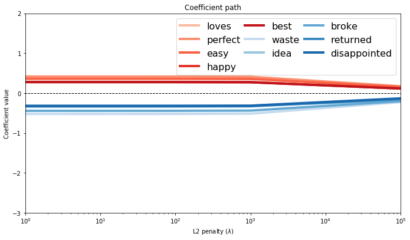

```python
make_coefficient_plot(table, positive_words, negative_words, l2_penalty_list=[0, 4, 10, 1e2, 1e3, 1e5])
```

**Quiz Question**: (**True**/False) Overall, all coefficients generally get smaller in size as the L2 penalty is increased.